# `par`

Element

A logical subdivison of textual content.

Typst automatically collects *inline-level* elements into paragraphs. Inline-level elements include text, horizontal spacing, boxes, and inline equations.

To separate paragraphs, use a blank line (or an explicit `parbreak`). Paragraphs are also automatically interrupted by any block-level element (like `block`, `place`, or anything that shows itself as one of these).

The `par` element is primarily used in set rules to affect paragraph properties, but it can also be used to explicitly display its argument as a paragraph of its own. Then, the paragraph’s body may not contain any block-level content.

## Boxes and blocks

As explained above, usually paragraphs only contain inline-level content. However, you can integrate any kind of block-level content into a paragraph by wrapping it in a `box`.

Conversely, you can separate inline-level content from a paragraph by wrapping it in a `block`. In this case, it will not become part of any paragraph at all. Read the following section for an explanation of why that matters and how it differs from just adding paragraph breaks around the content.

## What becomes a paragraph?

When you add inline-level content to your document, Typst will automatically wrap it in paragraphs. However, a typical document also contains some text that is not semantically part of a paragraph, for example in a heading or caption.

The rules for when Typst wraps inline-level content in a paragraph are as follows:

- All text at the root of a document is wrapped in paragraphs.
- Text in a container (like a `block`) is only wrapped in a paragraph if the container holds any block-level content. If all of the contents are inline-level, no paragraph is created.

In the laid-out document, it’s not immediately visible whether text became part of a paragraph. However, it is still important for various reasons:

- Certain paragraph styling like `first-line-indent` will only apply to proper paragraphs, not any text. Similarly, `par` show rules of course only trigger on paragraphs.
- A proper distinction between paragraphs and other text helps people who rely on Assistive Technology (AT) (such as screen readers) navigate and understand the document properly.
- PDF export will generate a `P` tag only for paragraphs.
- HTML export will generate a `<p>` tag only for paragraphs.

When creating custom reusable components, you can and should take charge over whether Typst creates paragraphs. By wrapping text in a `block` instead of just adding paragraph breaks around it, you can force the absence of a paragraph. Conversely, by adding a `parbreak` after some content in a container, you can force it to become a paragraph even if it’s just one word. This is, for example, what non-`tight` lists do to force their items to become paragraphs.

## Example

```
#set par(
  first-line-indent: 1em,
  spacing: 0.65em,
  justify: true,
)

We proceed by contradiction.
Suppose that there exists a set
of positive integers $a$, $b$, and
$c$ that satisfies the equation
$a^n + b^n = c^n$ for some
integer value of $n > 2$.

Without loss of generality,
let $a$ be the smallest of the
three integers. Then, we ...
```

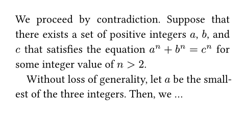

## Parameters

```
par(
  leading: length,
  spacing: length,
  justify: bool,
  justification-limits: dictionary,
  linebreaks: auto or str,
  first-line-indent: length or dictionary,
  hanging-indent: length,
  content,
) → content
```

### `leading`

length Settable

Default: `0.65em`

The spacing between lines.

Leading defines the spacing between the bottom edge of one line and the top edge of the following line. By default, these two properties are up to the font, but they can also be configured manually with a text set rule.

By setting top edge, bottom edge, and leading, you can also configure a consistent baseline-to-baseline distance. You could, for instance, set the leading to `1em`, the top-edge to `0.8em`, and the bottom-edge to `-0.2em` to get a baseline gap of exactly `2em`. The exact distribution of the top- and bottom-edge values affects the bounds of the first and last line.

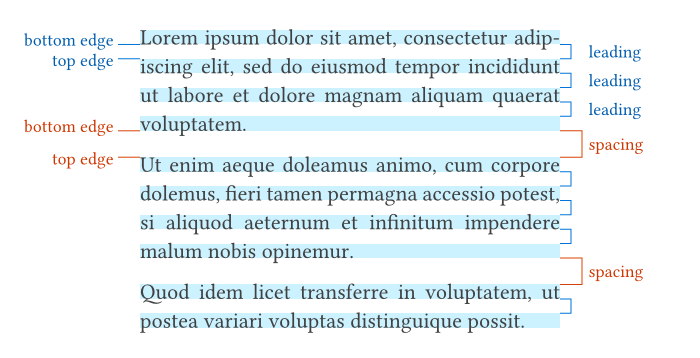

### `spacing`

length Settable

Default: `1.2em`

The spacing between paragraphs.

Just like leading, this defines the spacing between the bottom edge of a paragraph’s last line and the top edge of the next paragraph’s first line. Spacing acts both above and below, collapsing to the greater of the amounts defined by adjacent paragraphs.

When a paragraph is adjacent to a `block`, that block’s `above` or `below` property takes precedence over the paragraph spacing. Headings, for instance, reduce the spacing below them by default for a better look.

### `justify`

bool Settable

Default: `false`

Whether to justify text in its line.

Hyphenation will be enabled for justified paragraphs if the text function’s `hyphenate` property is set to `auto` and the current language is known.

Note that the current alignment still has an effect on the placement of the last line except if it ends with a justified line break.

By default, Typst only changes the spacing between words to achieve justification. However, you can also allow it to adjust the spacing between individual characters using the `justification-limits` property.

### `justification-limits`

dictionary Settable

Default:

```
(
spacing: (min: 66.67% + 0pt, max: 150% + 0pt),
tracking: (min: 0pt, max: 0pt),
)
```

How much the spacing between words and characters may be adjusted during justification.

When justifying text, Typst needs to stretch or shrink a line to the full width of the measure. To achieve this, by default, it adjusts the spacing between words. Additionally, it can also adjust the spacing between individual characters. This property allows you to configure lower and upper bounds for these adjustments.

The property accepts a dictionary with two entries, `spacing` and `tracking`, each containing a dictionary with the keys `min` and `max`. The `min` keys define down to which lower bound gaps may be shrunk while the `max` keys define up to which upper bound they may be stretched.

- The `spacing` entry defines how much the width of spaces between words may be adjusted. It is closely related to `text.spacing` and its `min` and `max` keys accept relative lengths, just like the `spacing` property.

  A `min` value of `100%` means that spaces should retain their normal size (i.e. not be shrunk), while a value of `90% - 0.01em` would indicate that a space can be shrunk to a width of 90% of its normal width minus 0.01× the current font size. Similarly, a `max` value of `100% + 0.02em` means that a space’s width can be increased by 0.02× the current font size. The ratio part must always be positive. The length part, meanwhile, must not be positive for `min` and not be negative for `max`.

  Note that spaces may still be expanded beyond the `max` value if there is no way to justify the line otherwise. However, other means of justification (e.g. spacing apart characters if the `tracking` entry is configured accordingly) are first used to their maximum.
- The `tracking` entry defines how much the spacing between letters may be adjusted. It is closely related to `text.tracking` and its `min` and `max` keys accept lengths, just like the `tracking` property. Unlike `spacing`, it does not accept relative lengths because the base of the relative length would vary for each character, leading to an uneven visual appearance. The behavior compared to `spacing` is as if the base was `100%`.

  Otherwise, the `min` and `max` values work just like for `spacing`. A `max` value of `0.01em` means that additional spacing amounting to 0.01× of the current font size may be inserted between every pair of characters. Note that this also includes the gaps between spaces and characters, so for spaces the values of `tracking` act in addition to the values for `spacing`.

If you only specify one of `spacing` or `tracking`, the other retains its previously set value (or the default if it was not previously set).

If you want to enable character-level justification, a good value for the `min` and `max` keys is around `0.01em` to `0.02em` (negated for `min`). Using the same value for both gives a good baseline, but tweaking the two values individually may produce more balanced results, as demonstrated in the example below. Be careful not to set the bounds too wide, as it quickly looks unnatural.

Using character-level justification is an impactful microtypographical technique that can improve the appearance of justified text, especially in narrow columns. Note though that character-level justification does not work with every font or language. For example, cursive fonts connect letters. Using character-level justification would lead to jagged connections.

**View example: Character-level justification**

```
#let example(name) = columns(2, gutter: 10pt)[
  #place(top, float: true, scope: "parent", strong(name))
  /* Text from https://en.wikipedia.org/wiki/Anne_Bayley */
]

#set page(width: 440pt, height: 21em, margin: 15pt)
#set par(justify: true)
#set text(size: 0.8em)

#grid(
  columns: (1fr, 1fr),
  gutter: 20pt,
  {
    // These are Typst's default limits.
    set par(justification-limits: (
      spacing: (min: 100% * 2 / 3, max: 150%),
      tracking: (min: 0em, max: 0em),
    ))
    example[Word-level justification]
  },
  {
    // These are our custom character-level limits.
    set par(justification-limits: (
      tracking: (min: -0.01em, max: 0.02em),
    ))
    example[Character-level justification]
  },
)
```

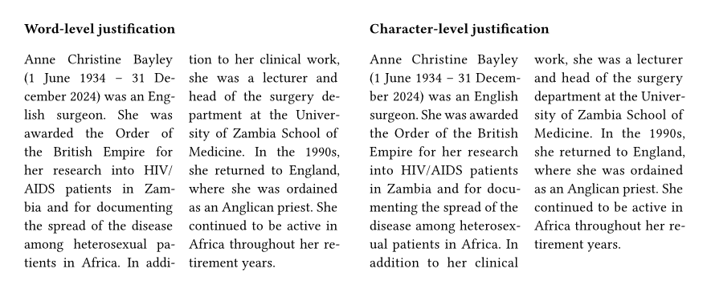

### `linebreaks`

auto or str Settable

Default: `auto`

How to determine line breaks.

When this property is set to `auto`, its default value, optimized line breaks will be used for justified paragraphs. Enabling optimized line breaks for ragged paragraphs may also be worthwhile to improve the appearance of the text.

**View example**

```
#set page(width: 207pt)
#set par(linebreaks: "simple")
Some texts feature many longer
words. Those are often exceedingly
challenging to break in a visually
pleasing way.

#set par(linebreaks: "optimized")
Some texts feature many longer
words. Those are often exceedingly
challenging to break in a visually
pleasing way.
```

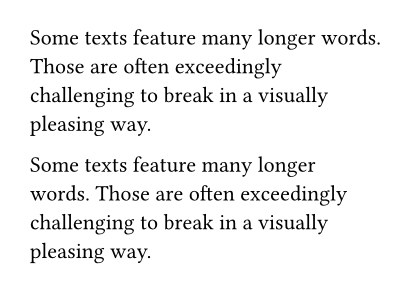

| **Variant** | **Details** |
| --- | --- |
| `"simple"` | Determine the line breaks in a simple first-fit style. |
| `"optimized"` | Optimize the line breaks for the whole paragraph. Typst will try to produce more evenly filled lines of text by considering the whole paragraph when calculating line breaks. |

### `first-line-indent`

length or dictionary Settable

Default: `(amount: 0pt, all: false)`

The indent the first line of a paragraph should have.

By default, only the first line of a consecutive paragraph will be indented (not the first one in the document or container, and not paragraphs immediately following other block-level elements).

If you want to indent all paragraphs instead, you can pass a dictionary containing the `amount` of indent as a length and the pair `all: true`. When `all` is omitted from the dictionary, it defaults to `false`.

By typographic convention, paragraph breaks are indicated either by some space between paragraphs or by indented first lines. Consider

- reducing the paragraph `spacing` to the `leading` using `set par(spacing: 0.65em)`
- increasing the block `spacing` (which inherits the paragraph spacing by default) to the original paragraph spacing using `set block(spacing: 1.2em)`

**View example**

```
#set block(spacing: 1.2em)
#set par(
  first-line-indent: 1.5em,
  spacing: 0.65em,
)

The first paragraph is not affected
by the indent.

But the second paragraph is.

#line(length: 100%)

#set par(first-line-indent: (
  amount: 1.5em,
  all: true,
))

Now all paragraphs are affected
by the first line indent.

Even the first one.
```

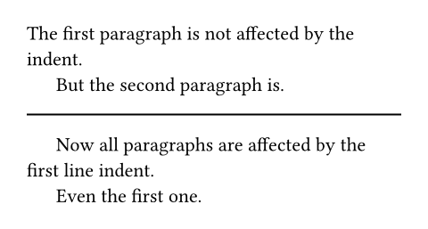

### `hanging-indent`

length Settable

Default: `0pt`

The indent that all but the first line of a paragraph should have.

**View example**

```
#set par(hanging-indent: 1em)

#lorem(15)
```

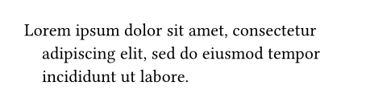

### `body`

content Required Positional

The contents of the paragraph.

## Definitions

### `line`

Element

A paragraph line.

This element is exclusively used for line number configuration through set rules and cannot be placed.

The `numbering` option is used to enable line numbers by specifying a numbering format.

**View example**

```
#set par.line(numbering: "1")

Roses are red. \
Violets are blue. \
Typst is there for you.
```

[figure not shown]

The `numbering` option takes either a predefined numbering pattern or a function returning styled content. You can disable line numbers for text inside certain elements by setting the numbering to `none` using show-set rules.

**View example**

```
// Styled red line numbers.
#set par.line(
  numbering: n => text(red)[#n]
)

// Disable numbers inside figures.
#show figure: set par.line(
  numbering: none
)

Roses are red. \
Violets are blue.

#figure(
  caption: [Without line numbers.]
)[
  Lorem ipsum \
  dolor sit amet
]

The text above is a sample \
originating from distant times.
```

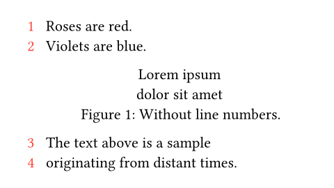

This element exposes further options which may be used to control other aspects of line numbering, such as its alignment or margin. In addition, you can control whether the numbering is reset on each page through the `numbering-scope` option.

```
par.line(
  numbering: none or str or function,
  number-align: auto or alignment,
  number-margin: alignment,
  number-clearance: auto or length,
  numbering-scope: str,
) → content
```

#### `numbering`

none or str or function Settable

Default: `none`

How to number each line. Accepts a numbering pattern or function taking a single number.

**View example**

```
#set par.line(numbering: "I")

Roses are red. \
Violets are blue. \
Typst is there for you.
```

[figure not shown]

**View example**

```
#set par.line(
  numbering: i => if calc.rem(i, 5) == 0 or i == 1 { i },
)

#lorem(60)
```

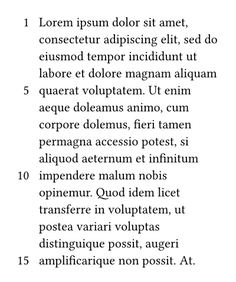

#### `number-align`

auto or alignment Settable

Default: `auto`

The alignment of line numbers associated with each line.

The default of `auto` indicates a smart default where numbers grow horizontally away from the text, considering the margin they’re in and the current text direction.

**View example**

```
#set par.line(
  numbering: "I",
  number-align: left,
)

Hello world! \
Today is a beautiful day \
For exploring the world.
```

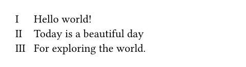

#### `number-margin`

alignment Settable

Default: `start`

The margin at which line numbers appear.

*Note:* In a multi-column document, the line numbers for paragraphs inside the last column will always appear on the `end` margin (right margin for left-to-right text and left margin for right-to-left), regardless of this configuration. That behavior cannot be changed at this moment.

**View example**

```
#set par.line(
  numbering: "1",
  number-margin: right,
)

= Report
- Brightness: Dark, yet darker
- Readings: Negative
```

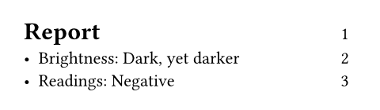

#### `number-clearance`

auto or length Settable

Default: `auto`

The distance between line numbers and text.

The default value of `auto` results in a clearance that is adaptive to the page width and yields reasonable results in most cases.

**View example**

```
#set par.line(
  numbering: "1",
  number-clearance: 4pt,
)

Typesetting \
Styling \
Layout
```

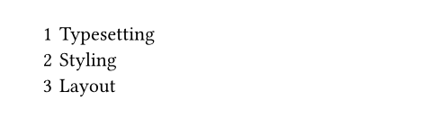

#### `numbering-scope`

str Settable

Default: `"document"`

Controls when to reset line numbering.

*Note:* The line numbering scope must be uniform across each page run (a page run is a sequence of pages without an explicit pagebreak in between). For this reason, set rules for it should be defined before any page content, typically at the very start of the document.

**View example**

```
#set par.line(
  numbering: "1",
  numbering-scope: "page",
)

First line \
Second line
#pagebreak()
First line again \
Second line again
```

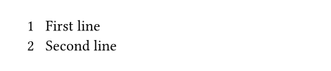

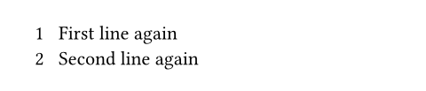

| **Variant** | **Details** |
| --- | --- |
| `"document"` | Indicates that the line number counter spans the whole document, i.e., it’s never automatically reset. |
| `"page"` | Indicates that the line number counter should be reset at the start of every new page. |

© Typst GmbH and contributors  
Licensed under the Apache License, Version 2.0.  
https://typst.app/docs/reference/model/par/